# Pipes, missing data and ggplot

Author

Dr. Niloufar Abourashchi and Dr. Thomas Honnor

## Workshop Agenda

### Today’s Tasks

1- Introduction to R Notebook

2- Using `Pipes`

3- Handling missing data

4- Practicing Tidyverse skills with the Gapminder Dataset

5- Introduction to Plotting with `ggplot2`

## Introduction to R Notebook

R Notebooks provide a powerful and flexible way to interactively develop and share your R code. They allow you to combine code, output, and narrative text in a single document, making them ideal for data analysis, exploration, and reporting.

. Getting Started with R Notebooks

1- Creating an R Notebook

- Open RStudio.
- Go to `File > New File > R Notebook`.

2- Structure of an R Notebook

- An R Notebook consists of text chunks and code chunks.
- Text chunks are written in Markdown.
- Code chunks are written in R and are enclosed by triple back ticks with `{r}` at the beginning.
- You can run the code chunks individually and see the output immediately below the chunk

**Simple code block in R Notebook**

```r
#This is a code chunk
print("Hello")
```

```
[1] "Hello"
```

- Follow this link for more information on [R Markdown](http://rmarkdown.rstudio.com) .

**Using R Notebook and Tidyverse function for `hsb2` dataset**

- We will address some questions from the Day 3 document by utilizing tidyverse functions and documenting our code within an R Notebook.

```r
library(tidyverse)
library(DT)
```

```r
highschool_raw <- read_csv("hsb2.csv")
datatable(highschool_raw, options = list(pagelength= 5, autoWidth=TRUE))
```

|  | id | female | race | ses | schtyp | prog | read | write | math | science | socst |
| --- | --- | --- | --- | --- | --- | --- | --- | --- | --- | --- | --- |
| 1 | 70 | 0 | 4 | 1 | 1 | 1 | 57 | 52 | 41 | 47 | 57 |
| 2 | 121 | 1 | 4 | 2 | 1 | 3 | 68 | 59 | 53 | 63 | 61 |
| 3 | 86 | 0 | 4 | 3 | 1 | 1 | 44 | 33 | 54 | 58 | 31 |
| 4 | 141 | 0 | 4 | 3 | 1 | 3 | 63 | 44 | 47 | 53 | 56 |
| 5 | 172 | 0 | 4 | 2 | 1 | 2 | 47 | 52 | 57 | 53 | 61 |
| 6 | 113 | 0 | 4 | 2 | 1 | 2 | 44 | 52 | 51 | 63 | 61 |
| 7 | 50 | 0 | 3 | 2 | 1 | 1 | 50 | 59 | 42 | 53 | 61 |
| 8 | 11 | 0 | 1 | 2 | 1 | 2 | 34 | 46 | 45 | 39 | 36 |
| 9 | 84 | 0 | 4 | 2 | 1 | 1 | 63 | 57 | 54 | 58 | 51 |
| 10 | 48 | 0 | 3 | 2 | 1 | 2 | 57 | 55 | 52 | 50 | 51 |

[output cut: 190 more lines]

### changing the levels enteries to labels using `mutate`

```r
highschool <- mutate(highschool_raw,
                     race = factor(race, levels = c(1,2,3,4),
                                         labels = c("hispanic",
                                                    "asian",
                                                    "african-american",
                                                    "white")),
                     ses = factor(ses, levels = c(1,2,3),
                                       labels = c("low",
                                                  "middle",
                                                  "high")),
                     schtyp = factor(schtyp, levels = c(1,2),
                                       labels = c("public",
                                                  "private")),
                     gender = factor(female, levels = c(0,1),
                                       labels = c("male",
                                                  "female"))
                     )
highschool <- select(highschool, -female)
highschool
```

```
# A tibble: 200 × 11
      id race          ses   schtyp  prog  read write  math science socst gender
   <dbl> <fct>         <fct> <fct>  <dbl> <dbl> <dbl> <dbl>   <dbl> <dbl> <fct>
 1    70 white         low   public     1    57    52    41      47    57 male
 2   121 white         midd… public     3    68    59    53      63    61 female
 3    86 white         high  public     1    44    33    54      58    31 male
 4   141 white         high  public     3    63    44    47      53    56 male
 5   172 white         midd… public     2    47    52    57      53    61 male
 6   113 white         midd… public     2    44    52    51      63    61 male
 7    50 african-amer… midd… public     1    50    59    42      53    61 male
 8    11 hispanic      midd… public     2    34    46    45      39    36 male
 9    84 white         midd… public     1    63    57    54      58    51 male
10    48 african-amer… midd… public     2    57    55    52      50    51 male
# ℹ 190 more rows
```

### renaming columns with `rename`

```r
highschool <- rename(highschool,
                     socioeconomic_group = ses,
                     racial_group = race,
                     school_type = schtyp,
                     )
highschool
```

```
# A tibble: 200 × 11
      id racial_group    socioeconomic_group school_type  prog  read write  math
   <dbl> <fct>           <fct>               <fct>       <dbl> <dbl> <dbl> <dbl>
 1    70 white           low                 public          1    57    52    41
 2   121 white           middle              public          3    68    59    53
 3    86 white           high                public          1    44    33    54
 4   141 white           high                public          3    63    44    47
 5   172 white           middle              public          2    47    52    57
 6   113 white           middle              public          2    44    52    51
 7    50 african-americ… middle              public          1    50    59    42
 8    11 hispanic        middle              public          2    34    46    45
 9    84 white           middle              public          1    63    57    54
10    48 african-americ… middle              public          2    57    55    52
# ℹ 190 more rows
# ℹ 3 more variables: science <dbl>, socst <dbl>, gender <fct>
```

### Examples of tidyverse code

**Average scores for girls from public school**

```r
highschool1 <- filter(highschool,
                      gender == "female",
                      school_type == "public"
                      )
summarise(highschool1,
          mean(read),
          mean(write),
          mean(math),
          mean(socst))
```

```
# A tibble: 1 × 4
  `mean(read)` `mean(write)` `mean(math)` `mean(socst)`
         <dbl>         <dbl>        <dbl>         <dbl>
1         51.4          54.7         52.2          52.7
```

**Average scores for African-american students**

```r
highschool2 <- filter(highschool, racial_group == "african-american")

summarise(highschool2,
          mean(read),
          mean(write),
          mean(math),
          mean(socst))
```

```
# A tibble: 1 × 4
  `mean(read)` `mean(write)` `mean(math)` `mean(socst)`
         <dbl>         <dbl>        <dbl>         <dbl>
1         46.8          48.2         46.8          49.4
```

**Data frame containing only student scores**

```r
# scores <- select(highschool,
#                  read,
#                  write,
#                  math,
#                  science,
#                  socst)
# better way

scores <- select(highschool, id, read:socst )

scores
```

```
# A tibble: 200 × 6
      id  read write  math science socst
   <dbl> <dbl> <dbl> <dbl>   <dbl> <dbl>
 1    70    57    52    41      47    57
 2   121    68    59    53      63    61
 3    86    44    33    54      58    31
 4   141    63    44    47      53    56
 5   172    47    52    57      53    61
 6   113    44    52    51      63    61
 7    50    50    59    42      53    61
 8    11    34    46    45      39    36
 9    84    63    57    54      58    51
10    48    57    55    52      50    51
# ℹ 190 more rows
```

### Pipes

Pipes `%>%` allow you to chain commands together, making your code more readable and efficient. The `tidyverse` package provides the pipe operator, and it is also included in the `dplyr` package.

**Pipe operators : `hsb2` data**

- Now that we are familiar with the hsb2 data, let’s use the pipe operator to make our code more efficient and avoid creating multiple data subsets.
- The following code demonstrates how to use the pipe operator to mutate, remove a column, and rename variables in the dataset, applying all these changes efficiently in a single pipeline:
- In this code:
- `mutate(new_column = some_transformation(existing_column))`: Adds a new column by transforming an existing one.
- `select(-unwanted_column)`: Removes the specified column.
- `rename(new_name1 = old_name1, new_name2 = old_name2)`: Renames specified columns.
- Using the pipe operator (%>%), all these operations are performed sequentially and the resulting dataset is assigned back to hsb2.

```r
highschool <- read_csv("hsb2.csv") %>%
  mutate(race = factor(race, levels = c(1,2,3,4),
                             labels = c("hispanic",
                                        "asian",
                                        "african-american",
                                        "white")),
         ses = factor(ses, levels = c(1,2,3),
                           labels = c("low",
                                      "middle",
                                      "high")),
         schtyp = factor(schtyp, levels = c(1,2),
                           labels = c("public",
                                      "private")),
         gender = factor(female, levels = c(0,1),
                           labels = c("male",
                                      "female"))) %>%
  select(-female) %>%
  rename( socioeconomic_group = ses,
          racial_group = race,
          school_type = schtyp)
highschool
```

```
# A tibble: 200 × 11
      id racial_group    socioeconomic_group school_type  prog  read write  math
   <dbl> <fct>           <fct>               <fct>       <dbl> <dbl> <dbl> <dbl>
 1    70 white           low                 public          1    57    52    41
 2   121 white           middle              public          3    68    59    53
 3    86 white           high                public          1    44    33    54
 4   141 white           high                public          3    63    44    47
 5   172 white           middle              public          2    47    52    57
 6   113 white           middle              public          2    44    52    51
 7    50 african-americ… middle              public          1    50    59    42
 8    11 hispanic        middle              public          2    34    46    45
 9    84 white           middle              public          1    63    57    54
10    48 african-americ… middle              public          2    57    55    52
# ℹ 190 more rows
# ℹ 3 more variables: science <dbl>, socst <dbl>, gender <fct>
```

- The following code provides a score_summary for females who are from public schools using the pipe operator to filter, summarize, and format the data:

**Example**

- In this code
- Filtering Data:`filter(gender == "female", school_type == "public")`: Selects rows where the gender column is “female” and the school_type column is “public”.
- `select(read:socst)`: Selects columns from read to socst. These columns typically represent different subjects such as reading, math, science, and social studies.
- `summarise_all(mean)`: Computes the mean (average) for each selected column. This operation calculates the average score for each subject across all female students in public schools.
- After executing this code, `score_summary` will contain a single row of data with the average scores for reading, math, science, and social studies among female students attending public high schools.

```r
score_summary <- highschool %>%
  filter(gender == "female", school_type == "public") %>%
  select(read:socst) %>%
  summarise_all(mean)

score_summary
```

```
# A tibble: 1 × 5
   read write  math science socst
  <dbl> <dbl> <dbl>   <dbl> <dbl>
1  51.4  54.7  52.2    50.5  52.7
```

### Handling Missing Data

Dealing with missing data is essential for maintaining data integrity. The `tidyverse` package offers several functions for this purpose.

- In this course, we will use drop_na() and na.rm = TRUE for handling missing data, highlighting their differences:
- `drop_na():` Removes rows containing missing values (NA).
- Typically used in data cleaning and preprocessing to exclude incomplete observations.
- `na.rm = TRUE:`Used in functions like mean(), sum(), etc.
- Computes statistics while ignoring missing values (NA).
- Applied within specific functions to handle missing data during calculation.

**Warning**

- `drop_na()` removes entire rows with any missing values, affecting the dataset’s structure.
- ``na.rm = TRUE` is applied within functions to compute statistics on specific columns or variables without considering missing values.
  - `drop_na()` alters dataset dimensions by reducing the number of rows, while `na.rm = TRUE` affects only the calculation of specific summary statistics.

Understanding these distinctions is crucial for effectively managing missing data in data analysis and ensuring accurate results in statistical computations.

- To demonstrate the effects of missing data using `hsb2_missing_data.csv`, you can illustrate how missing values impact data analysis and processing.

**Example**

```r
highschool <- read_csv("hsb2_missing_data.csv") %>%
  mutate(race = factor(race, levels = c(1,2,3,4),
                             labels = c("hispanic",
                                        "asian",
                                        "african-american",
                                        "white")),
         ses = factor(ses, levels = c(1,2,3),
                           labels = c("low",
                                      "middle",
                                      "high")),
         schtyp = factor(schtyp, levels = c(1,2),
                           labels = c("public",
                                      "private")),
         gender = factor(female, levels = c(0,1),
                           labels = c("male",
                                      "female"))) %>%
  select(-female) %>%
  rename( socioeconomic_group = ses,
          racial_group = race,
          school_type = schtyp)
summary(highschool)
```

```
       id                   racial_group socioeconomic_group  school_type
 Min.   :  1.00   hispanic        : 22   low   :47           public :168
 1st Qu.: 50.75   asian           : 11   middle:95           private: 32
 Median :100.50   african-american: 20   high  :58
 Mean   :100.50   white           :143
 3rd Qu.:150.25   NA's            :  4
 Max.   :200.00

      prog           read           write            math          science
 Min.   :1.00   Min.   :28.00   Min.   :31.00   Min.   :33.00   Min.   :26.00
 1st Qu.:2.00   1st Qu.:44.00   1st Qu.:46.00   1st Qu.:45.00   1st Qu.:44.00
 Median :2.00   Median :51.00   Median :54.00   Median :52.50   Median :53.00
 Mean   :2.02   Mean   :52.31   Mean   :52.84   Mean   :52.75   Mean   :51.92
 3rd Qu.:2.00   3rd Qu.:60.00   3rd Qu.:60.00   3rd Qu.:59.00   3rd Qu.:58.00
 Max.   :3.00   Max.   :76.00   Max.   :67.00   Max.   :75.00   Max.   :77.00
 NA's   :1      NA's   :2       NA's   :2       NA's   :2       NA's   :2
     socst          gender
 Min.   :26.00   male  : 89
 1st Qu.:46.00   female:107
 Median :52.00   NA's  :  4
 Mean   :52.41
 3rd Qu.:61.00
 Max.   :71.00
```

```r
sum(complete.cases(highschool))
```

```
[1] 189
```

```r
nrow(highschool)
```

```
[1] 200
```

```r
# calculating mean of column with missing data gives NA
mean(highschool$math)
```

```
[1] NA
```

```r
# use option na.rm=T to force R to ignore missing values
mean(highschool$math, na.rm=T)
```

```
[1] 52.74747
```

```r
# the other option is to drop incomplete rows from the data frame
highschool_complete <- drop_na(highschool)

sum(complete.cases(highschool_complete))
```

```
[1] 189
```

```r
nrow(highschool_complete)
```

```
[1] 189
```

```r
mean(highschool_complete$math)
```

```
[1] 52.61905
```

```r
score_summary <- highschool %>%
  drop_na() %>%
  filter(gender == "female", school_type == "public") %>%
  select(read:socst) %>%
  summarise_all(mean)

score_summary
```

```
# A tibble: 1 × 5
   read write  math science socst
  <dbl> <dbl> <dbl>   <dbl> <dbl>
1  51.7  55.1  52.7    50.9  53.1
```

## Introducing ggplot2: Exploring Children Body Size Data

In this section, we will focus on the children_bodysize dataset and utilize `ggplot2` to gain deeper insights into the data.

- Load and manipulate the `children_bodysize dataset` using pipes and dplyr from the tidyverse, and then we will demonstrate various visualizations.

#### Loading and preparing the dataset

```r
library(tidyverse)

# Load and preprocess the children_bodysize dataset
bodysize <- read_csv("children_bodysize.csv") %>%
  mutate(height = stature / 10,      # Convert stature to height (assuming stature is in cm)
         age = age / 12,             # Convert age to years (assuming age is in months)
         year_old = floor(age),     # Calculate age in whole years
         gender = factor(gender))   # Convert gender to factor for categorical plotting
```

#### Scatter Plot of Height vs. Age

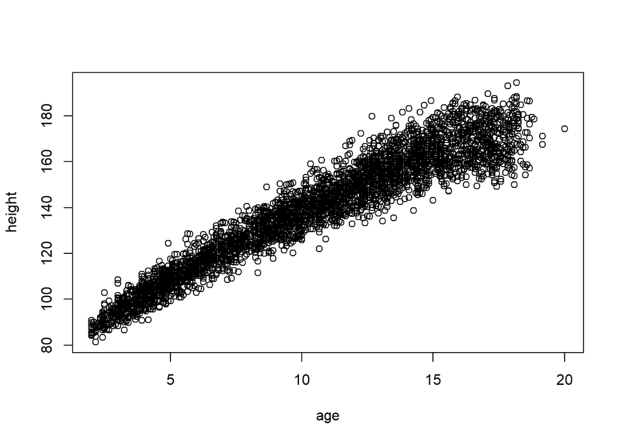

```r
plot(height~age, data=bodysize)
```

#### Basic Scatter Plot with `ggplot2`

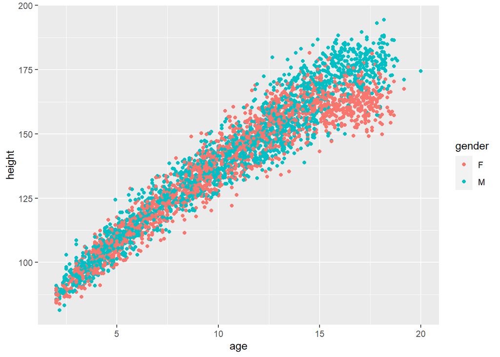

```r
ggplot() +
  geom_point(data = bodysize,
             mapping = aes(x=age, y=height, color=gender) )
```

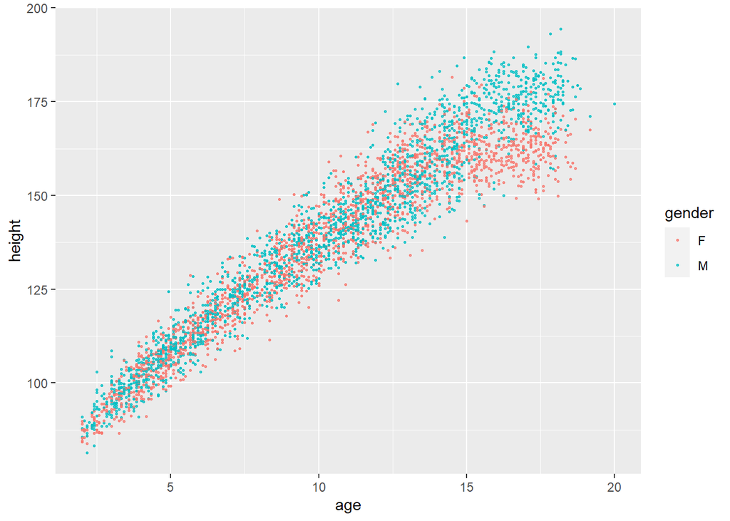

```r
ggplot() +
  geom_point(data = bodysize,
             mapping = aes(x=age, y=height,
                           color=gender),
             size=0.5,
             alpha=0.8)
```

#### Density Plot of Height by Gender for 15-Year-Olds

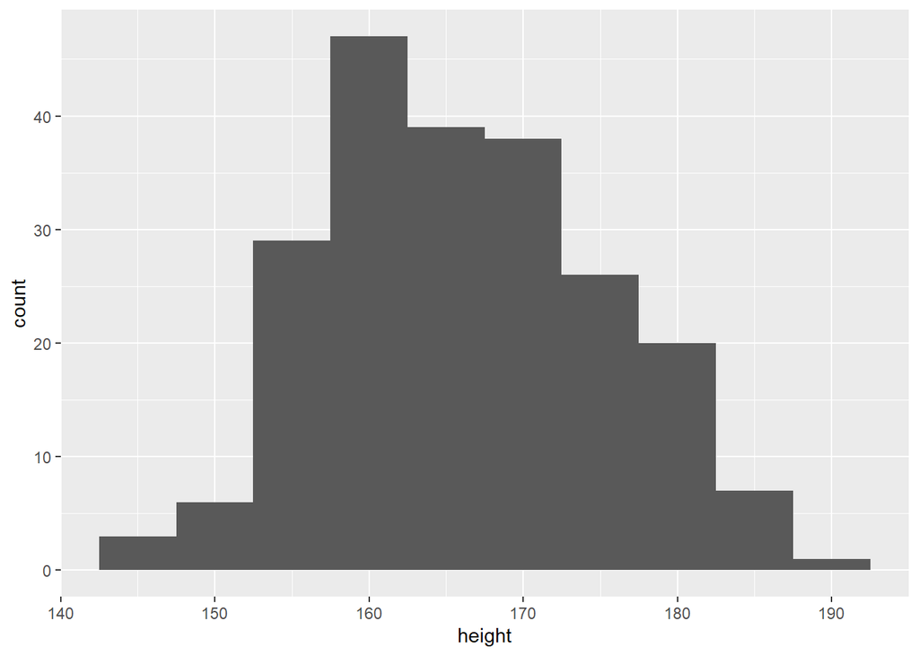

```r
ggplot() +
  geom_histogram(data=filter(bodysize, year_old==15),
                 mapping = aes(x = height),
                 binwidth=5)
```

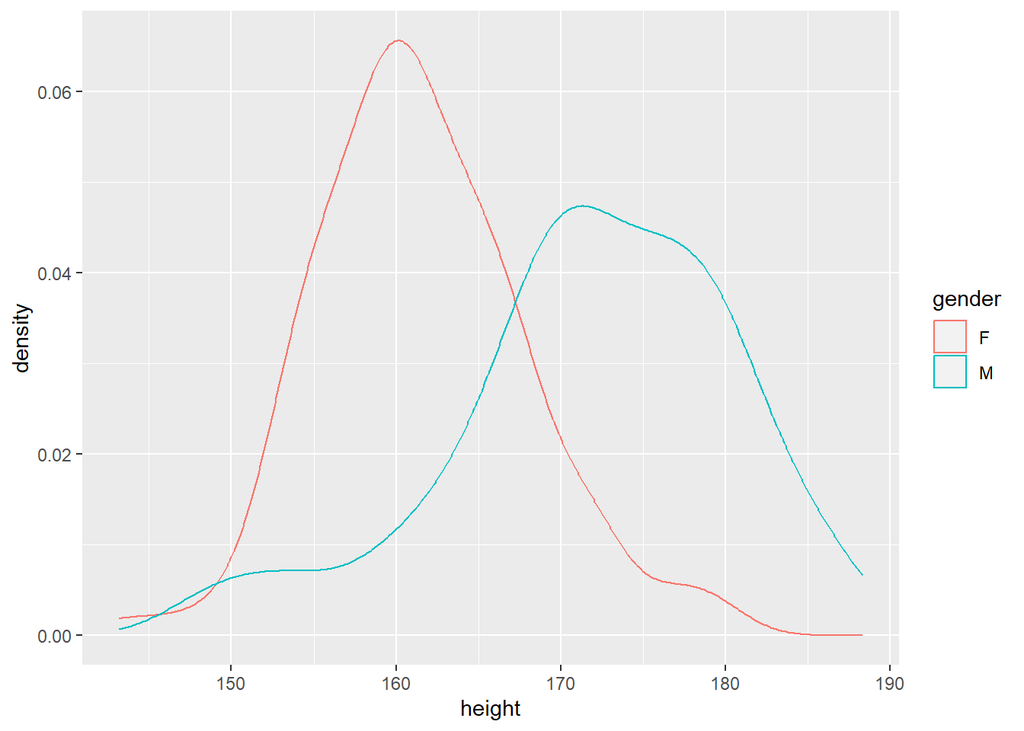

```r
ggplot() +
  geom_density(data=filter(bodysize, year_old==15),
                 mapping = aes(x = height, color=gender))
```

#### Violin Plot of Height Distribution by Gender for 15-Year-Olds

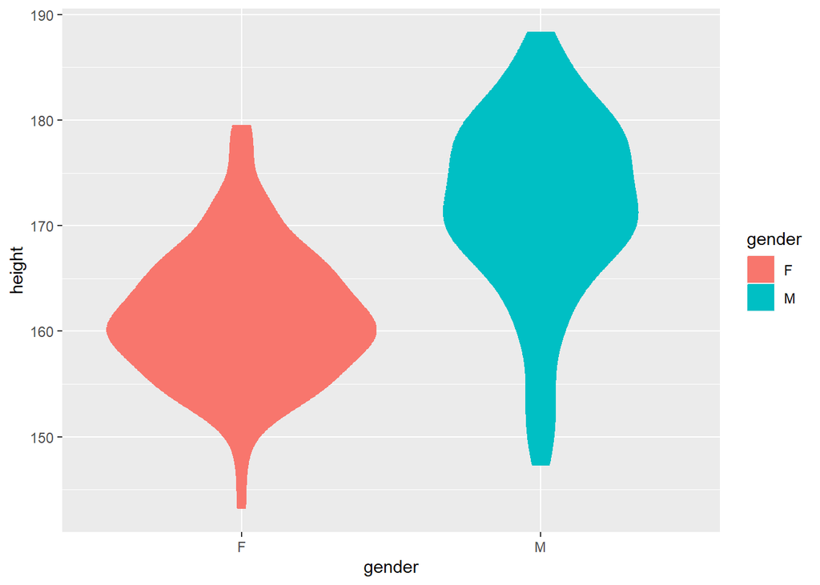

```r
ggplot() +
  geom_violin(data=filter(bodysize, year_old==15),
                 mapping = aes(y = height, x=gender, color=gender, fill=gender))
```

#### Scatter Plot with Smoothed Line by Gender

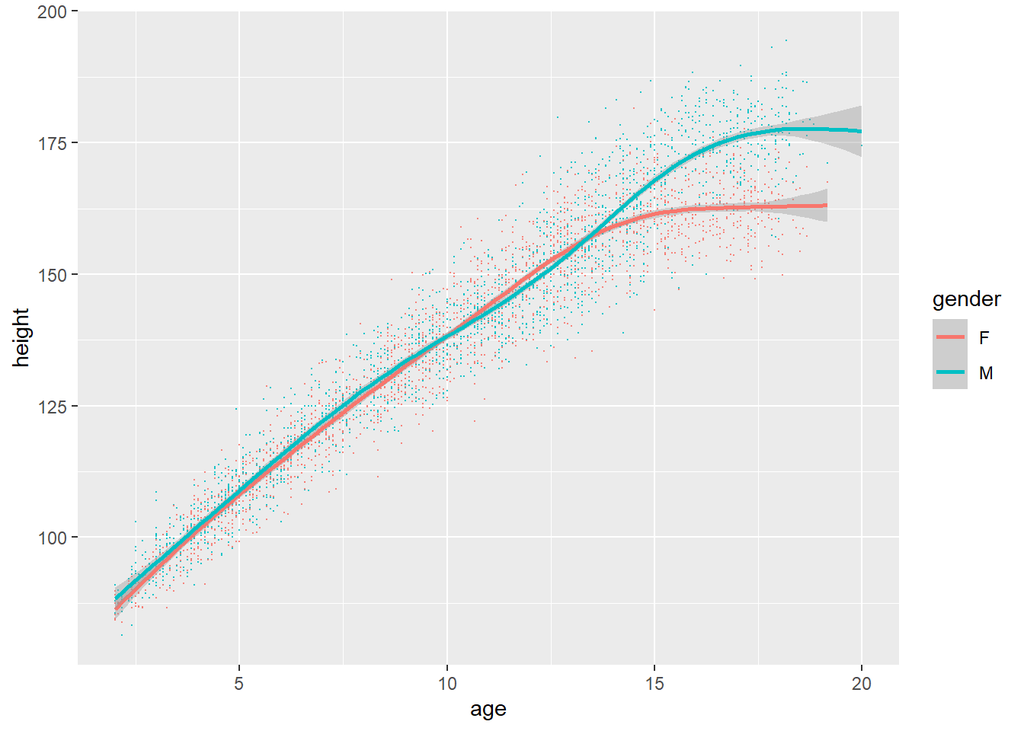

```r
ggplot(data = bodysize,
       mapping = aes(x=age, y=height, color=gender)) +
  geom_point(size=0.1,alpha=0.8) +
  geom_smooth()
```

#### Scatter Plot with Smoothed Line by Gender with Faceting

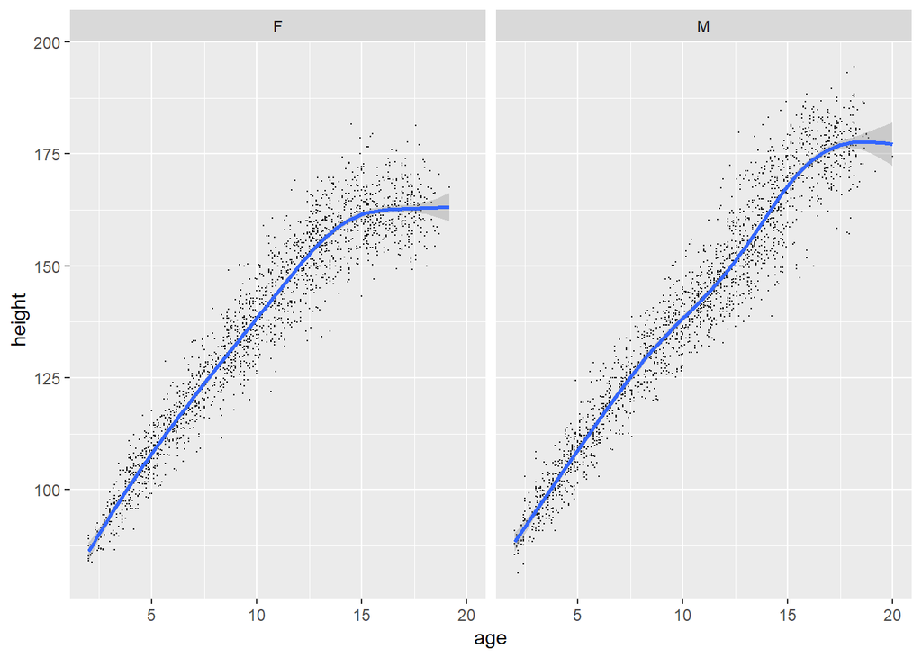

```r
ggplot(data = bodysize,
       mapping = aes(x=age, y=height)) +
  geom_point(size=0.1,alpha=0.8) +
  geom_smooth() + facet_wrap(~gender)
```

#### Density Plot of Height by Gender Faceted by Age Group

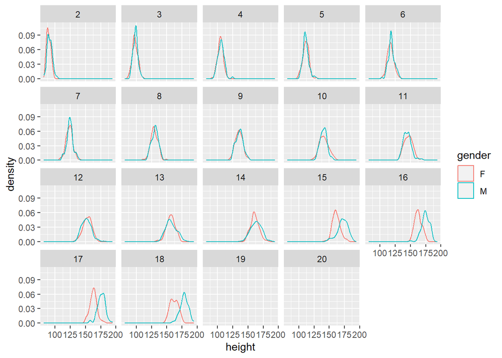

```r
ggplot(data = bodysize) +
  geom_density( mapping = aes(x = height, color=gender) ) +
  facet_wrap(~year_old)
```

#### Density Plot of Height by Gender for Ages 13 to 17

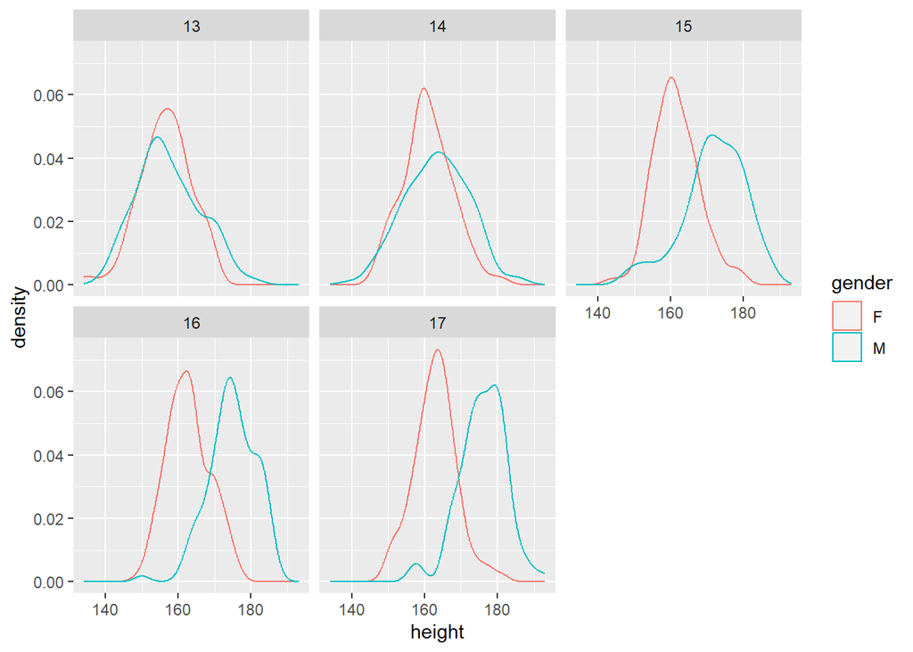

```r
bodysize %>%
  filter(age>=13, age<18) %>%
  ggplot() +
    geom_density( mapping = aes(x = height, color=gender) ) +
    facet_wrap(~year_old)
```

#### Jitter Plot of Foot Length by Age in Years

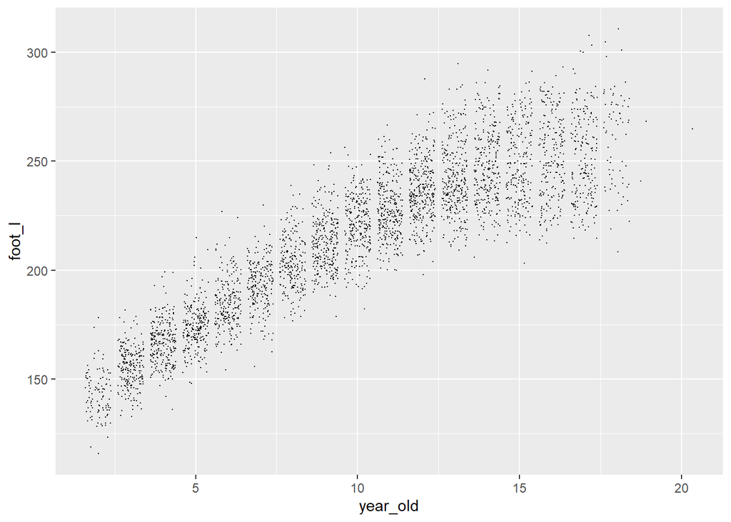

```r
bodysize %>%
  ggplot(mapping = aes(x=year_old, y=foot_l)) +
  geom_jitter(size=.1)
```

These examples demonstrate how to effectively use `ggplot2` for exploratory data analysis and visualization of the children_bodysize dataset. Adjust parameters such as `binwidth`, `size`, `alpha`, and `facet_wrap` as needed to refine your visualizations and gain insights into the data.